# FigureYa307CNVHeatmap

**Author(s)**: Xiaofan Lu; Yasi Zhang  
**Reviewer(s)**: Ying Ge  
**Date**: `r Sys.Date()`

# Academic Citation

If you use this code in your work or research, we kindly request that you cite our publication:

Xiaofan Lu, et al. (2025). FigureYa: A Standardized Visualization Framework for Enhancing Biomedical Data Interpretation and Research Efficiency. iMetaMed. https://doi.org/10.1002/imm3.70005

# 需求描述

# Demand description

希望画出拷贝数变异的图。

I want to plot copy number variation (CNV) profiles.

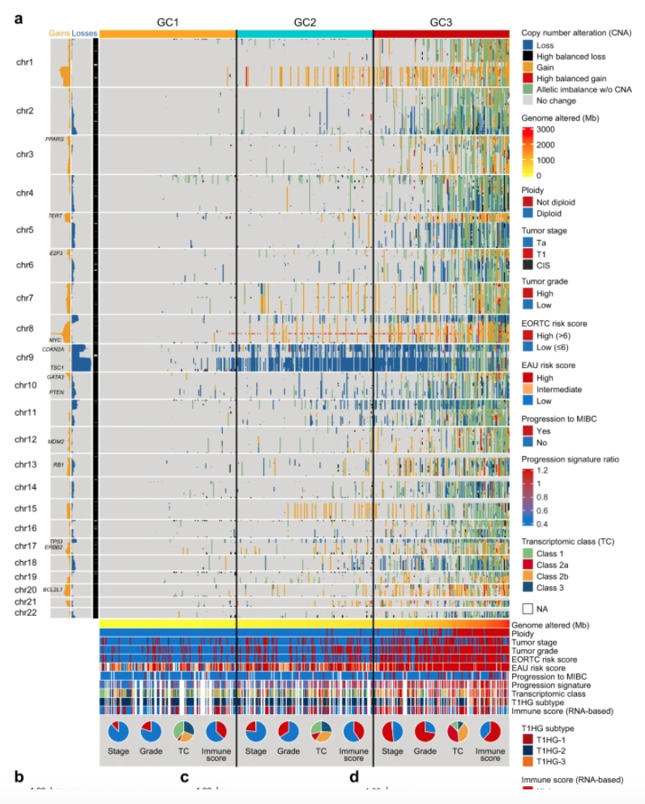

出自：https://www.nature.com/articles/s41467-021-22465-w

图2：非肌层浸润性膀胱癌(NMIBC)的拷贝数变异情况。 a. 按基因组类别(GC 1-3)分层的473个肿瘤的全基因组拷贝数景观图。增益(增益+高平衡增益)和缺失(缺失+高平衡缺失)汇总显示在染色体条带面板左侧。EORTC - 欧洲癌症研究与治疗组织，EAU - 欧洲泌尿外科协会，MIBC - 肌层浸润性膀胱癌

Suorce: https://www.nature.com/articles/s41467-021-22465-w

Fig. 2: Copy number alterations in NMIBC. a. Genome-wide copy number landscape of 473 tumors stratified by genomic class (GC) 1–3. Gains (gain + high balanced gain) and losses (loss + high balanced loss) are summarized to the left of the chromosome band panel. EORTC European Organisation for Research and Treatment of Cancer, EAU European Association of Urology, MIBC muscle-invasive bladder cancer.

# 应用场景

# Application scenarios

利用GISTIC算法的输出文件，绘制拷贝数热图（不包含底部饼图）。

我们实现过一些突变相关以及富集分析的图，可灵活运用，画出文中的图：

- Figure 1ah共识聚类及热图，可参考FigureYa202consensusGene
- Figure 1b桑基图，画法可参考FigureYa25sankey
- Figure 1cd、2bcd、3c、4e、5c、多亚型生存分析，可参考FigureYa284pairwiseLogrank或FigureYa1survivalCurve
- Figure 2a，本文档将带你实现。只画左侧频率对比图，可参考FigureYa79CNV
- Figure 3e突变综合热图，可参考FigureYa248MutLandscape
- Figure 5a森林图，可参考FigureYa90subgroup

Copy Number Heatmap Generation Using GISTIC Output Files (Excluding Bottom Pie Chart).

We have several mutation-related and enrichment analysis plots, which can be flexibly adapted to reproduce the figures in this study:

- Figure 1a&h: Consensus clustering and heatmap, refer to FigureYa202consensusGene
- Figure 1b: Sankey diagram, refer to FigureYa25sankey
- Figures 1c-d, 2b-d, 3c, 4e, 5c: Multi-subtype survival analysis, refer to FigureYa284pairwiseLogrank or FigureYa1survivalCurve
- Figure 2a: This document will guide you through its implementation. For the left-side frequency comparison plot only, refer to FigureYa79CNV
- Figure 3e: Integrated mutation heatmap, refer to FigureYa248MutLandscape
- Figure 5a: Forest plot, refer to FigureYa90subgroup

# 环境设置

# Environment Setup

```r
source("install_dependencies.R")
```

[output not shown]

```r
library(ComplexHeatmap)
# 如果是用hg38的基因组请加载:
# Load if using hg38 genome reference:
#library(TxDb.Hsapiens.UCSC.hg38.knownGene)

# 如果是用hg38的基因组请加载:
# Load if using hg38 genome reference:
library(TxDb.Hsapiens.UCSC.hg19.knownGene)
# 用于获取基因位点信息
# For gene locus information
library(trackViewer)

library(org.Hs.eg.db)
library(ggplot2)

# 用于获取TCGA数据的分子亚型信息
# For TCGA molecular subtype data
library(TCGAbiolinks)

library(dplyr)
library(RColorBrewer)
library(circlize)
# 显示英文报错信息
# Show English error messages
Sys.setenv(LANGUAGE = "en")

# 禁止chr转成factor
# Prevent character-to-factor conversion
options(stringsAsFactors = FALSE)
```

自定义函数，用于获取基因位点

Custom function for retrieving gene loci

```r
getGeneLocation <- function(symbol, txdb, org){
  # 获取基因位置
  # trackViewer::getLocation的改进版，避免报错，增加GeneSymbol列
  # Get gene locations
  # Improved version of trackViewer::getLocation with error handling and added GeneSymbol column
  dbPrefix <- sub(".db", "", org)
  eg <- mget(symbol, get(paste0(dbPrefix, "SYMBOL2EG")), ifnotfound = NA)
  eg <- lapply(eg, `[`, i = 1)
  eg <- unlist(eg, use.names = TRUE)
  eg <- eg[!is.na(eg)]
  if (length(eg) < 1) {
    return(NULL)
  }
  genes <- genes(txdb)
  eg <- eg[eg%in%genes$gene_id]
  gr <- genes[eg]
  gr$symbol <- names(eg)
  seqlevelsStyle(gr) <- "UCSC"
  seqlevels(gr) <- seqlevels(gr)[seqlevels(gr) %in% as.character(seqnames(gr))]
  if (length(seqinfo(gr)) > 0) {
    seqinfo(gr) <- seqinfo(gr)[seqlevels(gr)]
  }
  return(gr)
}
```

# 输入文件

# Input files

这里以TCGA数据为例。TCGA_BLCA.all_thresholded.by_genes.txt，该文件为GISTIC算法的输出文件之一，也可在http://firebrowse.org/中获取已经分析好的GISTIC结果。

Using TCGA data as example. TCGA_BLCA.all_thresholded.by_genes.txt is one of the output files from GISTIC algorithm. Pre-analyzed GISTIC results can also be obtained from http://firebrowse.org/

```r
cnv <- read.table("TCGA_BLCA.all_thresholded.by_genes.txt", sep = "\t", row.names = 1, header = T, check.names = F)

## 构建基因*样本矩阵
## Construct gene × sample matrix
cnv$`Locus ID` = cnv$Cytoband = NULL
colnames(cnv) <- substr(colnames(cnv)[4:ncol(cnv)], 1, 12)
```

# 准备绘图数据

# Prepare plotting data

```r
## 获取每一行基因在染色体上的位置，并按顺序重排
## Get chromosomal positions for each gene and reorder
geneLocation <- as.data.frame(getGeneLocation(symbol = rownames(cnv),
                                              txdb = TxDb.Hsapiens.UCSC.hg19.knownGene,
                                              org = "org.Hs.eg.db"))
```

```
##   403 genes were dropped because they have exons located on both strands of the
##   same reference sequence or on more than one reference sequence, so cannot be
##   represented by a single genomic range.
##   Use 'single.strand.genes.only=FALSE' to get all the genes in a GRangesList
##   object, or use suppressMessages() to suppress this message.
```

```r
geneLocation$seqnames <- as.character(geneLocation$seqnames)
geneLocation <- geneLocation[which(geneLocation$seqnames %in% c("chr1","chr2","chr3","chr4","chr5","chr6","chr7","chr8","chr9","chr10","chr11",
                                                                "chr12","chr13","chr14","chr15","chr16","chr17","chr18","chr19","chr20","chr21","chr22")),]
geneLocation <- arrange(geneLocation, geneLocation$seqnames, geneLocation$start)
geneLocation$seqnames <- factor(geneLocation$seqnames, levels = c("chr1","chr2","chr3","chr4","chr5","chr6","chr7","chr8","chr9","chr10","chr11",
                                                                  "chr12","chr13","chr14","chr15","chr16","chr17","chr18","chr19","chr20","chr21","chr22"))

## 获取分子亚型信息
## Get molecular subtype information
classVar <- "Mutation.process.cluster"
sampleInfo <- data.frame(TCGAquery_subtype(tumor = "blca"))
```

```
## blca subtype information from:doi:10.1016/j.cell.2017.09.007
```

```r
sampleInfo <- sampleInfo[sampleInfo$patient %in% colnames(cnv), ]
sampleInfo <- arrange(sampleInfo, sampleInfo[[classVar]])
sampleInfo <- sampleInfo[sampleInfo[[classVar]] != "NA", ]

## 整理需要用来画图的样本信息(plot.sampleInfo)
## Prepare sample information for plotting (plot.sampleInfo)
cnv <- cnv[geneLocation$symbol, sampleInfo$patient]
plot.sampleInfo <- sampleInfo[, c("Noninvasive.bladder.history", "AJCC.pathologic.tumor.stage", "Number.of.LNs.examined")]
colnames(plot.sampleInfo) <- c("Noninvasive","AJCC.stage","Nb.LNs.examined")
plot.sampleInfo$Nb.LNs.examined <- as.numeric(plot.sampleInfo$Nb.LNs.examined)
```

# 开始画图

# Plotting

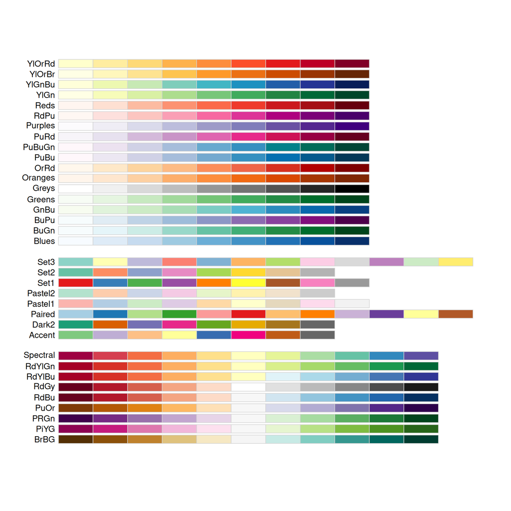

```r
## 指定左侧标注基因名的基因
## Specify genes to be labeled on the left side
plot.gene <- c("E2F3", "GATA3", "PTEN")

## 制作样本信息注释数据框
## Create sample annotation data frame
RColorBrewer::display.brewer.all()
```

```r
str(plot.sampleInfo)
```

```
## 'data.frame':    402 obs. of  3 variables:
##  $ Noninvasive    : chr  "ND" "ND" "ND" "ND" ...
##  $ AJCC.stage     : chr  "II" "III" "III" "III" ...
##  $ Nb.LNs.examined: num  16 14 22 14 47 19 NA 19 24 27 ...
```

```r
### 按照数据框顺序填写各列注释所使用的颜色
### Define colors for each annotation column following data frame order
sampleCol <- list(setNames(object = c("grey", "blue", "red"), nm = c("ND", "NO", "YES")),
                  setNames(object = c(brewer.pal(n = 4, name = "Set1"), "grey"),
                           nm = c("I", "II", "III", "IV", "ND")),
                  colorRamp2(breaks = c(0, 30), colors = c("#1874CB", "#CA0A07")))

# 为颜色列表赋上与样本信息相同的名字
# Assign same names as sample info
names(sampleCol) <- names(plot.sampleInfo)
col_ha = columnAnnotation(df = plot.sampleInfo, col = sampleCol,
                          simple_anno_size = unit(0.8, "cm"),
                          show_annotation_name = T, show_legend = T)

## 制作基因信息注释
## Create gene annotation
barCol <- ifelse(test = rowSums(cnv)>0, yes = "#ED9A15", no = "#245F9B")
row_ha = rowAnnotation(gene = anno_mark(at = match(plot.gene, rownames(cnv)),
                                        labels = plot.gene, side = "left"),
                       chr = anno_barplot(rowSums(cnv), bar_width = 0.8, border = FALSE,
                                          gp = gpar(fill = barCol, col = NA),
                                          # add_numbers = T, numbers_offset = unit(-10, "mm"),
                                          axis_param = list("labels_rot" = 0, direction = "reverse"),
                                          # numbers_gp = gpar(fontsize = 9, col = "white"),
                                          width = unit(1, "cm")),
                       show_annotation_name = F, show_legend = F)

# 绘制热图
# Generate heatmap
hm <- Heatmap(matrix = cnv,
              row_split = geneLocation$seqnames,
              bottom_annotation = col_ha, left_annotation = row_ha,
              column_split = sampleInfo[[classVar]],
              cluster_columns = T, cluster_rows = F, cluster_column_slices = F,
              col = c("#020000", "#245F9B", "#D8D6D4", "#ED9A15", "#D10909"),
              show_column_names = F, show_row_names = F,
              row_title_rot = 0,
              # width = unit(10, "cm"), height = unit(10, "cm"),
              show_heatmap_legend = T, show_column_dend = F)
```

```
## `use_raster` is automatically set to TRUE for a matrix with more than
## 2000 rows. You can control `use_raster` argument by explicitly setting
## TRUE/FALSE to it.
##
## Set `ht_opt$message = FALSE` to turn off this message.
```

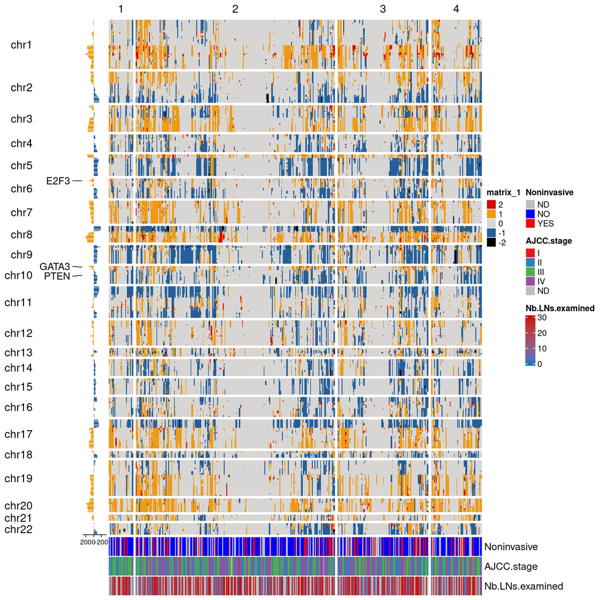

```r
hm
```

```r
pdf("CNVheatmap.pdf", width = 10,height = 10)
draw(hm, heatmap_legend_side = "right", annotation_legend_side = "right", merge_legend = TRUE)
invisible(dev.off())
```

# 后期处理

# Post-processing

底部饼图画法可参考FigureYa196PanPie

前面生成的PDF文件是矢量图文件，可以用Adobe Illustrator等矢量图编辑器打开编辑。

For bottom pie chart creation, refer to FigureYa196PanPie:

The previously generated PDF files are vector graphics that can be edited with vector editors like Adobe Illustrator.